# Step-by-step guide to the Coxmos pipeline

### Original variables

To generate a Kaplan-Meier curve for original variables, the “type” parameter must be set to “VAR” (variable). In this case, the “ori_data” parameter can be used to determine whether the original or normalized values of the variables should be used.

Additionally, the “top” parameter can be used to plot a specific number of variables, sorted by P-Value (Log-Rank test). The best cutpoint is determined by the “surv_cutpoint” function. Both qualitative and quantitative variables are supported.

```r
LST_KM_RES_VAR <- getAutoKM.list(type = "VAR",
                                 lst_models = lst_models,
                                 comp = 1:10, #select how many components you want to compute for the pseudo beta
                                 top = 10,
                                 ori_data = T, #original data selected
                                 BREAKTIME = NULL,
                                 only_sig = T, alpha = 0.05)
```

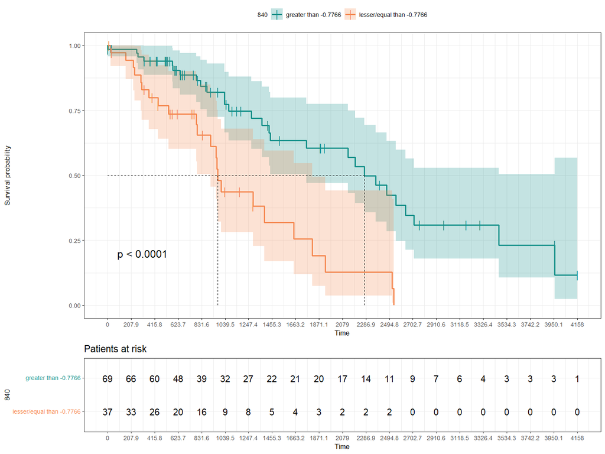

```r
LST_KM_RES_VAR$`sPLS-DRCOX`$LST_PLOTS$`840`
```

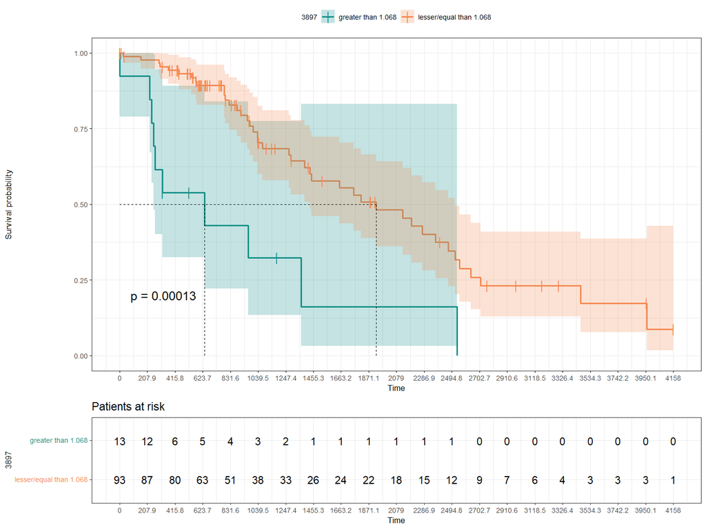

```r
LST_KM_RES_VAR$`sPLS-DRCOX`$LST_PLOTS$`3897`
```

```r
lst_cutoff <- getCutoffAutoKM.list(LST_KM_RES_VAR)

LST_KM_TEST_VAR <- getTestKM.list(lst_models = lst_models,
                                  X_test = X_test, Y_test = Y_test,
                                  type = "VAR", ori_data = T,
                                  BREAKTIME = NULL, n.breaks = 20,
                                  lst_cutoff = lst_cutoff)
```

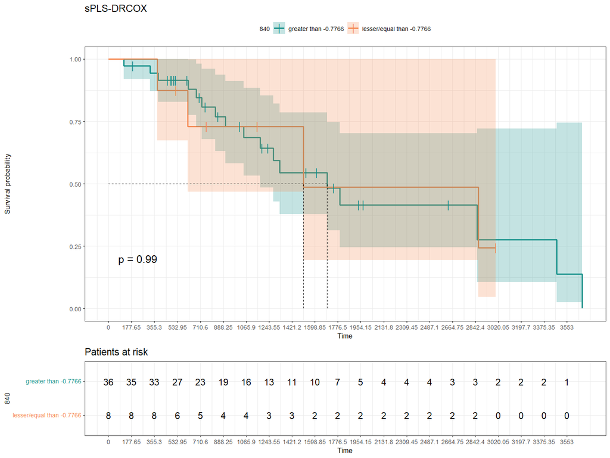

```r
LST_KM_TEST_VAR$`sPLS-DRCOX`$`840`
```

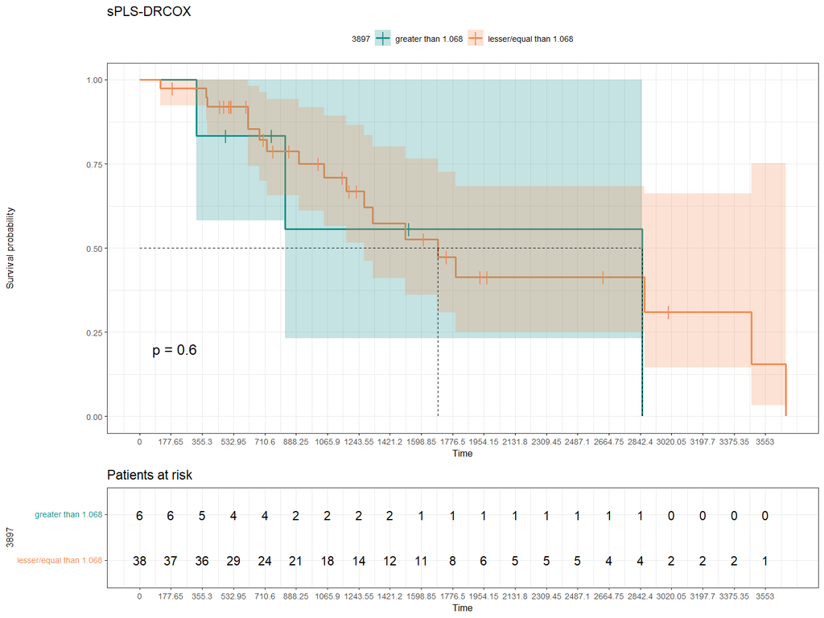

```r
LST_KM_TEST_VAR$`sPLS-DRCOX`$`3897`
```

# New patients

In addition, HDCox can also manage new patients to perform predictions.

To demonstrate, an observation from a test dataset will be used.

```r
new_pat <- X_test[1,,drop=F]
```

```r
knitr::kable(Y_test[rownames(new_pat),])
```

|  | time | event |
| --- | --- | --- |
| TCGA-A2-A0SV-01A | 825 | TRUE |

The function `plot_pseudobeta_newPatient.list()` or `plot_pseudobeta_newPatient()` allows the user to compare the characteristics of a new patient with the pseudo-beta values obtained from a specific model. The goal is to understand in a general way which variables are associated with an increased risk of an event or a decreased risk, in comparison to the variables predicted by the model.

```r
ggp.simulated_beta_newPat <- plot_pseudobeta_newPatient.list(lst_models = lst_models,
                                                             new_observation = new_pat,
                                                             error.bar = T, onlySig = T, alpha = 0.05,
                                                             zero.rm = T, auto.limits = T, show.betas = T, top = 20)
```

[output not shown]

```r
# ggp.simulated_beta_newPat <- plot_pseudobeta_newPatient(model = lst_models$`sPLS-DRCOX`,
#                                                         new_observation = new_pat,
#                                                         error.bar = T, onlySig = T, alpha = 0.05,
#                                                         zero.rm = T, auto.limits = T, show.betas = T, top = 20)
```

```r
ggp.simulated_beta_newPat$`sPLS-DRCOX`$plot
```

[output not shown]

## Add patient to density plot

```r
pat_density <- plot_observation.eventDensity(patient = new_pat,
                                             model = lst_models$`sPLS-DRCOX`,
                                             time = NULL,
                                             type = "lp")
```

[output not shown]

```r
pat_density
```

[output not shown]

```r
pat_histogram <- plot_observation.eventHistogram(patient = new_pat,
                                                 model = lst_models$`sPLS-DRCOX`,
                                                 time = NULL,
                                                 type = "lp")
```

[output not shown]

```r
pat_histogram
```

[output not shown]

## COX compare multiple patients

Furthermore, similar plots can be generated for multiple patients at the same time. For example, by selecting 5 patients, individual linear predictors for each variable and the final linear predictor using all the variables used in the survival model can be plotted.

As an idea, this function could also be used to study the same patient in different time points after receiving a treatment and study its own evolution related to the original variables.

```r
knitr::kable(Y_test[1:5,])
```

|  | time | event |
| --- | --- | --- |
| TCGA-A2-A0SV-01A | 825 | TRUE |
| TCGA-A2-A0YT-01A | 723 | TRUE |
| TCGA-BH-A1FB-01A | 3669 | TRUE |
| TCGA-D8-A1XC-01A | 377 | TRUE |
| TCGA-BH-A1EX-01A | 1508 | TRUE |

To generate the figure, the function `plot_LP.multiplePatients.list()` or `plot_LP.multiplePatients()` can be used.

```r
lst_cox.comparison <- plot_LP.multiplePatients.list(lst_models = lst_models,
                                                    new_data = X_test[1:5,],
                                                    error.bar = T, zero.rm = T, onlySig = T,
                                                    alpha = 0.05, top = 10)
```

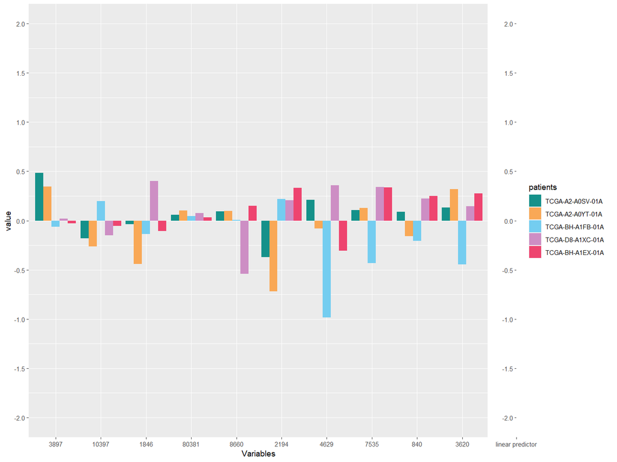

```r
lst_cox.comparison$`sPLS-DRCOX`$plot
```